# Course Project 1

Gabor Szalai

4 March 2016

This document is my submission for Course Project 1 on the Reproducible Research module.

## Loading and preprocessing the data

First let’s check whether the working directory contains the data file and if not, then download it from it’s original web URL and extract the .zip file.

```r
if ("activity.csv" %in% dir() == FALSE) {
download.file("https://d396qusza40orc.cloudfront.net/repdata%2Fdata%2Factivity.zip","activity monitoring data.zip")
unzip("activity monitoring data.zip")
}
```

Next, we read in the activity.csv file and transform the dates into a valid date format using the lubridate package.

```r
activity <- read.csv("activity.csv")
library(lubridate)
activity$date <- parse_date_time(as.character(activity$date),"Ymd")
```

## What is mean total number of steps taken per day?

First, we group the dataset by the date field using dplyr package. Then we summarise the total steps  
per day (ignoring missing values) and create a histogram of the summary data by using the ggplot 2 package.

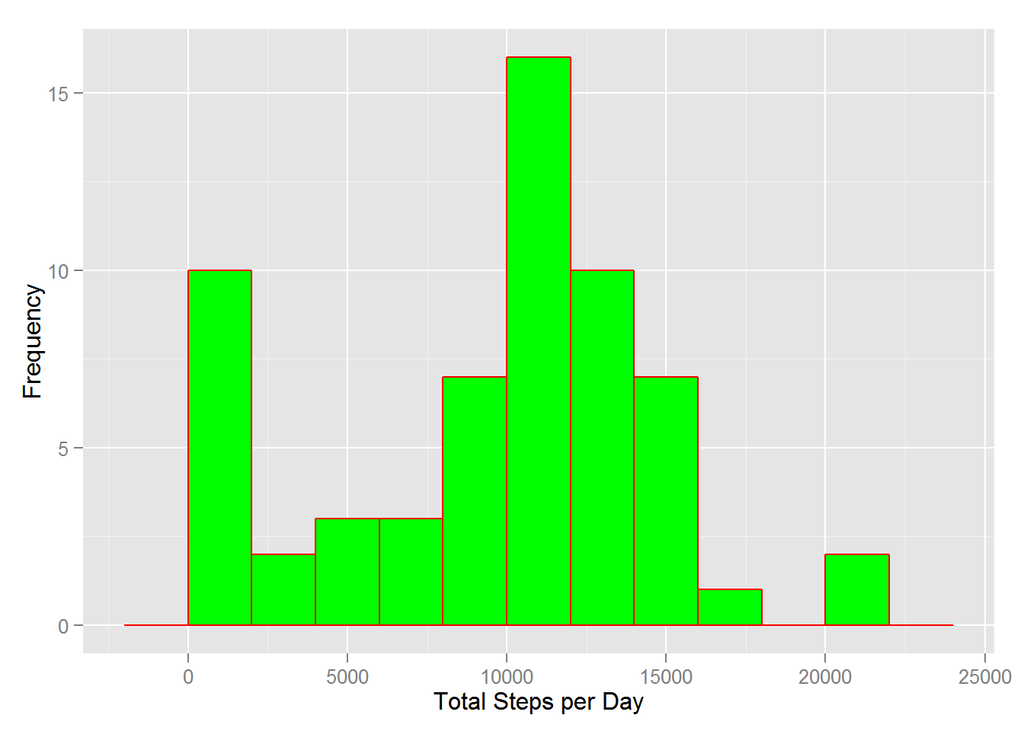

```r
library(dplyr)
library(ggplot2)
activity_bydate <- activity %>% group_by(date)
total1 <- activity_bydate %>% summarise(steps_total=sum(steps,na.rm=TRUE))
hist1 <- ggplot(total1, aes(steps_total)) +
                        geom_histogram(binwidth=2000,
                                col="red",
                                fill="green") +
                        labs(x="Total Steps per Day", y="Frequency")
plot(hist1)
```

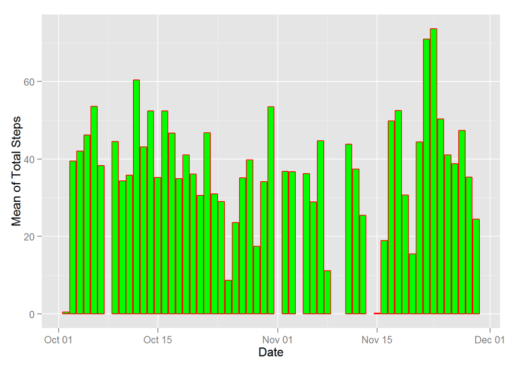

```r
mean1 <- activity_bydate %>% summarise(steps_mean=mean(steps,na.rm=TRUE))
median1 <- activity_bydate %>% summarise(steps_median=median(steps,na.rm=TRUE))

plot_mean1 <- ggplot(mean1, aes(date, steps_mean)) +
                geom_bar(stat = "identity",fill="green", col="red") +
                labs(x="Date", y="Mean of Total Steps")

plot_median1 <- ggplot(median1, aes(date, steps_median)) +
                 geom_bar(stat = "identity",fill="green",col="red") +
                labs(x="Date", y="Median of Total Steps")
plot(plot_mean1)
```

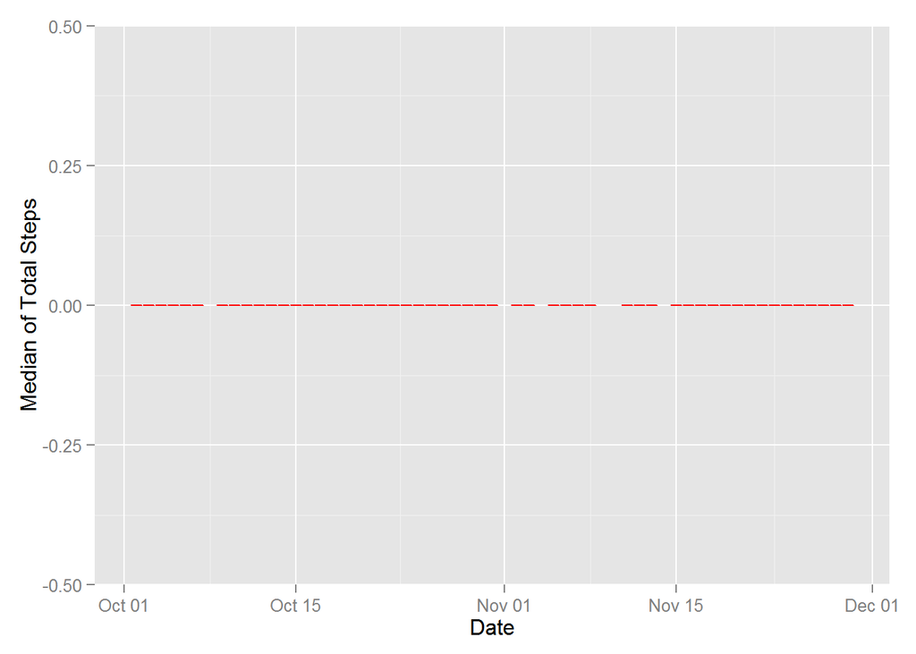

```r
plot(plot_median1)
```

## What is the average daily activity pattern?

First, we group the data by intervals. Then we calculate a summary for the intervals showing the average number of steps taken for the given interval as averaged across all the days. Then we plot the results and highlight the interval with the maximum amount of average steps. The interval’s ID number is displayed in the graph legends.

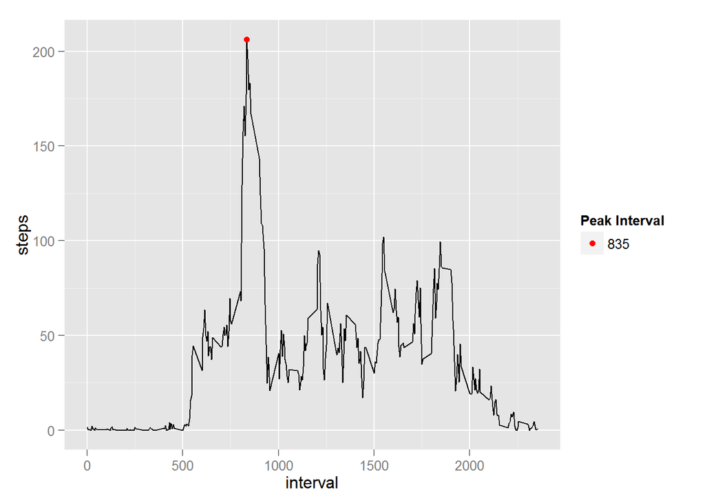

```r
interval_group <- activity %>% group_by(interval)
interval_avg <- interval_group %>% summarise(steps=mean(steps,na.rm=TRUE))
maximum <- interval_avg[interval_avg$steps== max(interval_avg$steps),]

cols2 <- c("A" = "red")
max_value <- as.character(maximum$interval)
names(cols2) <- max_value

plot <- ggplot(interval_avg, aes(interval, steps))
plot + geom_line(stat = "identity") +
geom_point(aes(x=maximum$interval,y=maximum$steps,color=max_value),size=2) +
scale_colour_manual(name="Peak Interval",values = cols2)
```

## Imputing missing values

First, we calculate and report the number of missing values in the dataset.

```r
missing <- activity[is.na(activity$steps == TRUE),]
missing_count <- nrow(missing)
```

The number of rows with NAs is **2304**.

Second, we will fill in the missing values. As a substitue, whenever the steps value is missing, we are going to replace NA with the rounded average number of steps for that given interval as averaged across all days. We do this with a for loop. Then we create a new activity2 dataset that uses the substituted values.

```r
for (i in 1:missing_count) {
        missing$steps[i] <- round(interval_avg$steps[interval_avg$interval == missing$interval[i]])
}
activity2 <- activity[!is.na(activity$steps == TRUE),]
activity2 <- rbind(activity2,missing)
```

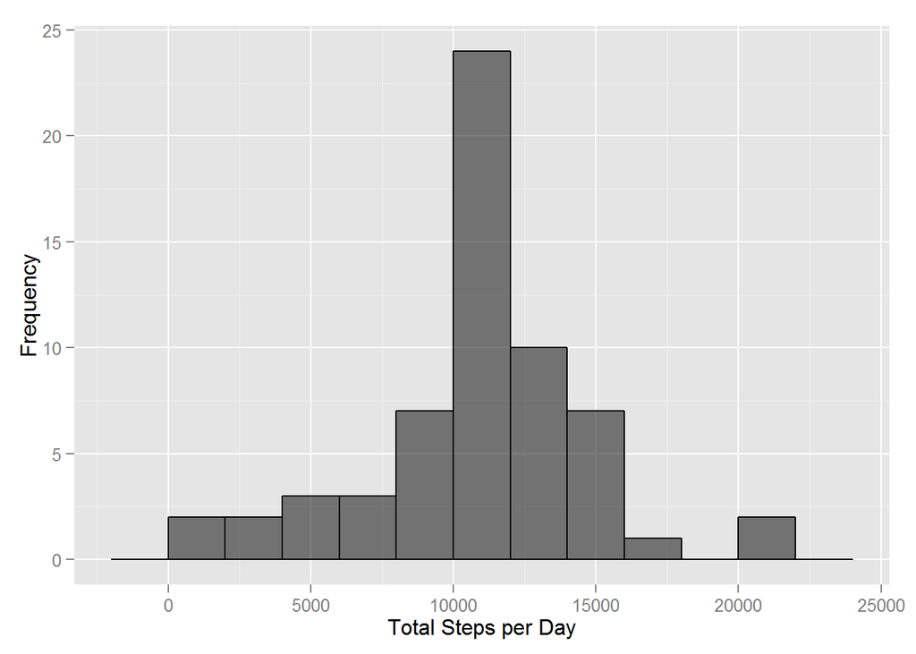

```r
activity2_bydate <- activity2 %>% group_by(date)
total2 <- activity2_bydate %>% summarise(steps_total=sum(steps,na.rm=TRUE))
hist2 <- ggplot(total2, aes(steps_total)) +
        geom_histogram(binwidth=2000,
                       col="black",
                       fill="black",alpha=0.5) +
        labs(x="Total Steps per Day", y="Frequency")
plot(hist2)
```

Now let’s compare the two histograms in a single plot. The old histogram is plotted in green colour and red border; whereas the new historgam is displayed dark gray color and black border. Overlapping areas will be shown as a dark green.

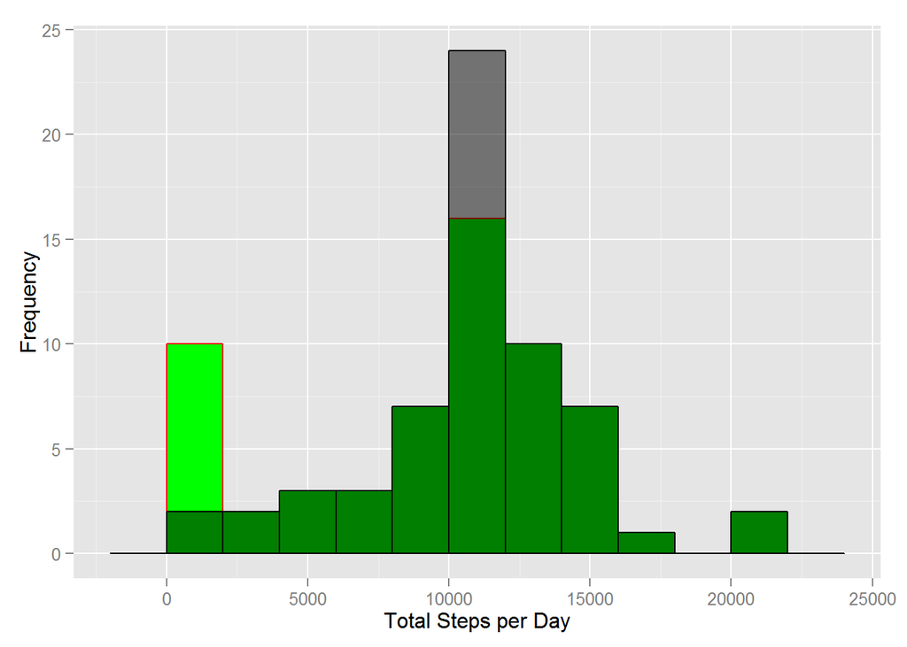

```r
hist_compare <- ggplot(total1, aes(steps_total)) +
        geom_histogram(binwidth=2000,
                       col="red",
                       fill="green",alpha=1) +
        geom_histogram(data=total2,aes(steps_total),binwidth=2000,
                       col="black",
                       fill="black",alpha=0.5) +
        labs(x="Total Steps per Day", y="Frequency")
plot(hist_compare)
```

As we can see, the main impact of the imputation was that the frequency of the lower values dropped significantly; whilst the frequency of the central values increased.

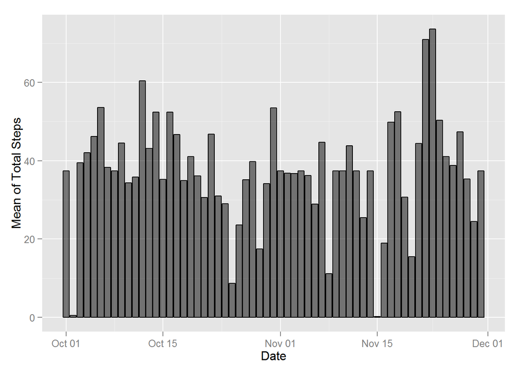

```r
mean2 <- activity2_bydate %>% summarise(steps_mean=mean(steps,na.rm=TRUE))
median2 <- activity2_bydate %>% summarise(steps_median=median(steps,na.rm=TRUE))

plot_mean2 <- ggplot(mean2, aes(date, steps_mean)) +
        geom_bar(stat = "identity",fill="black",alpha=0.5,col="black") +
        labs(x="Date", y="Mean of Total Steps")

plot_median2 <- ggplot(median2, aes(date, steps_median)) +
        geom_bar(stat = "identity",fill="black",alpha=0.5,col="black") +
        labs(x="Date", y="Median of Total Steps")

plot(plot_mean2)
```

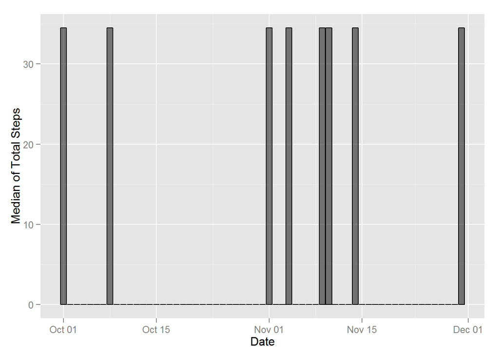

```r
plot(plot_median2)
```

And now let’s do the comparisons. The old-new distinction is represented in the same way as in case of the histrogram comparison.

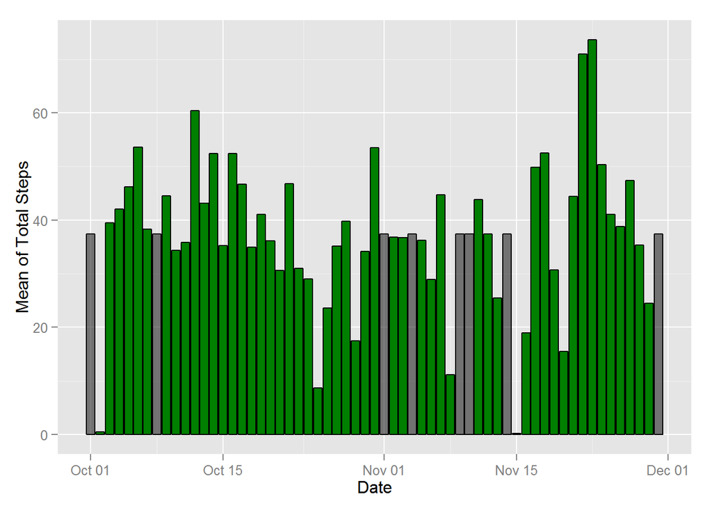

```r
plot_mean_comparison <- ggplot(mean1, aes(date, steps_mean)) +
        geom_bar(stat = "identity",fill="green",col="green") +
        geom_bar(data=mean2,aes(date,steps_mean),stat="identity",fill="black",alpha=0.5,col="black")+
        labs(x="Date", y="Mean of Total Steps")

plot(plot_mean_comparison)
```

As indicated, the main difference is that the imputed values filled up the gaps in the distribution chart.

If we compare the median stats in the same way, we will see this even more drammatically as previously there were no non-zero values.

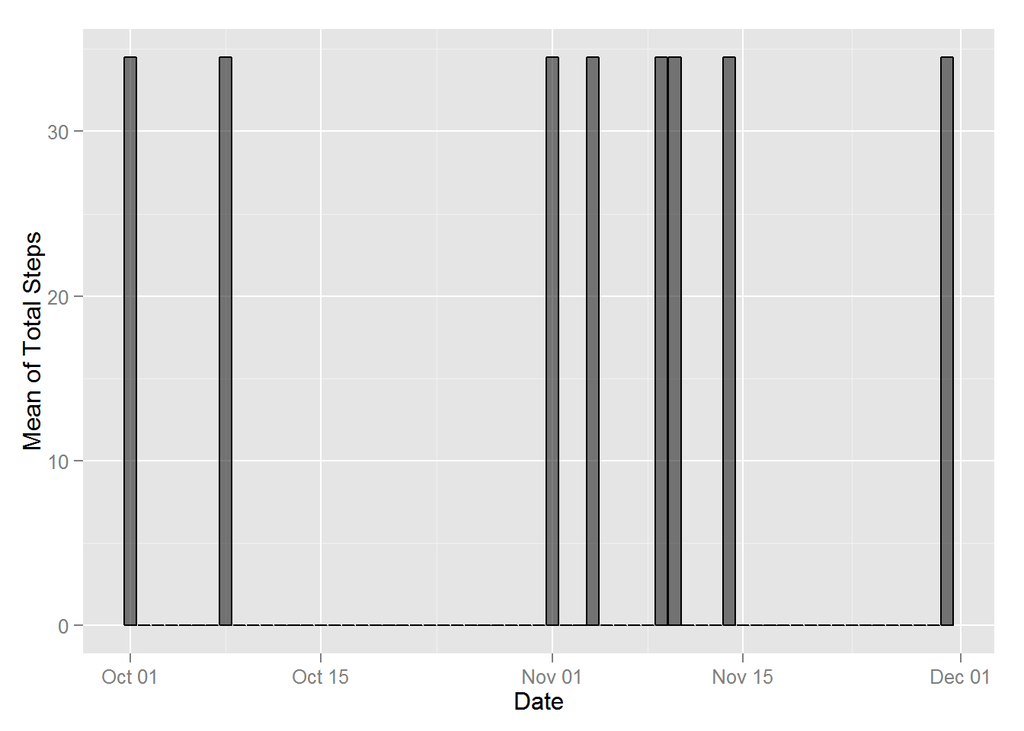

```r
plot_median_comparison <- ggplot(median1, aes(date, steps_median)) +
        geom_bar(stat = "identity",fill="green",col="green") +
        geom_bar(data=median2,aes(date,steps_median),stat="identity",fill="black",alpha=0.5,col="black")+
        labs(x="Date", y="Mean of Total Steps")

plot(plot_median_comparison)
```

## Are there differences in activity patterns between weekdays and weekends?

In the last task, we create a new factor variable in the imputed dataset with two levels – “weekday” and “weekend” indicating whether a given date is a weekday or weekend day.

```r
activity2$day <- sapply(activity2$date, function(f) {weekdays(f)})
activity2$weekday <- sapply(activity2$day, function(g) {
        if (g == "Saturday" | g == "Sunday") {
                g <- 'Weekend'}
                else {g <- "Weekday"}
                })

activity2$weekday <- as.factor(activity2$weekday)
```

After that, we group the data by the weekdday variable and the intervals and create a summary of the average of this grouped data.

```r
interval_group2 <- activity2 %>% group_by(weekday,interval)
interval_avg2 <- interval_group2 %>% summarise(steps=mean(steps,na.rm=TRUE))
```

Finally, we create a faceted time-series plot of the intervals and and average number of steps taken, averaged across weekdays and weekends.

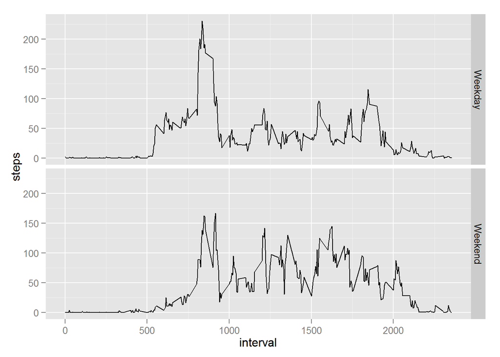

```r
timeseries <- ggplot(interval_avg2, aes(interval, steps,weekday))+
        geom_line(stat = "identity") +
        facet_grid(weekday ~ .)
plot(timeseries)
```